# Protocol for Preparation and Operation of the ChronoSeq Device for an Experiment.

### Optional Cell Collection from Multiple Reservoirs for qPCR testing two reservoirs at the same time

- For this optional schedule Cell Channel Sample Reservoir 3 was connected to the Cell Gas Vent Valve before proceeding.
- One Magnetic Stirrer was added to both Reservoir 3 and Reservoir 1 each.
- Reservoir 3 was also reoriented to make it closer to the Magnetic Stirrer.

```python
def build_time_point_and_cell_sample_scheduleList():
    timeAndCellTupleList=[((1,1),(2,3)),((3,1),(4,3)),((5,1),(6,3)),((7,1),(8,3)),((9,1),(10,3))] # Timepoint Collection Tube and Cell Reservoir Combination
    timepointAndCellScheduleList=[]
    for timeAndcellTuple in timeAndCellTupleList:
        total_run_time=183.0 #The rest of the run takes 160seconds
        timepointAndCellScheduleList.append((get_sample_cells_only_from_two_reservoirs,1,total_run_time,timeAndcellTuple))
    return timepointAndCellScheduleList

scheduleList=[]+build_time_point_and_cell_sample_scheduleList()

print(scheduleList)

execute_schedules(scheduleList,60.0*60.0,True) #Running every 1 hour for a total or four hours
```

```
[(<function get_sample_cells_only_from_two_reservoirs at 0x00000200B58F5AE8>, 1, 183.0, ((1, 1), (2, 3))), (<function get_sample_cells_only_from_two_reservoirs at 0x00000200B58F5AE8>, 1, 183.0, ((3, 1), (4, 3))), (<function get_sample_cells_only_from_two_reservoirs at 0x00000200B58F5AE8>, 1, 183.0, …
Stop Vent Executed!
Valve Controller 1 State successfully changed!
0 0 0 0 0 0 0 0 0 0 0 0 0 0 0 0
Valve Controller 2 State successfully changed!
0 0 0 0 0 0 0 0 0 0 0 0 0 0 0 0
Schedule 1 Started at 2025-06-30 23:51:35.598785
Starting Cell Collection from Reservoir at  2025-06-30 23:51:35.606763
Time point is : 1
Cell Sample valve number is: 1
0.0
Valve Controller 1 State successfully changed!
0 0 0 0 0 0 0 0 0 0 0 0 0 0 0 0
Valve Controller 2 State successfully changed!
0 0 1 0 0 0 0 0 0 1 0 0 0 0 0 0
Valve Controller 1 State successfully changed!
0 0 0 0 0 0 0 0 0 0 0 0 0 0 0 0
Valve Controller 2 State successfully changed!
0 0 0 0 0 0 0 0 1 1 0 0 0 0 0 0
Valve Controller 1 State successfully changed!
0 0 0 0 0 0 0 0 0 0 0 0 0 0 0 0
Valve Controller 2 State successfully changed!
0 0 0 0 0 0 0 0 1 0 0 0 0 0 0 0
Valve Controller 1 State successfully changed!
0 0 0 0 0 0 0 0 0 0 0 0 0 0 0 0
Valve Controller 2 State successfully changed!
0 0 0 0 0 0 0 0 1 1 0 0 0 0 0 0
0.0
Valve Controller 1 State successfully changed!
0 0 0 0 0 0 0 0 0 0 0 0 0 0 0 0
Valve Controller 2 State successfully changed!
0 0 1 0 0 0 0 0 0 0 0 0 0 0 0 0
Valve Controller 1 State successfully changed!
0 0 0 0 0 0 0 0 0 0 0 0 0 0 0 0
Valve Controller 2 State successfully changed!
0 0 1 0 0 0 0 0 0 1 0 0 0 0 0 0
Starting Cell Collection from Reservoir at  2025-06-30 23:53:35.709484
Time point is : 2
Cell Sample valve number is: 3
0.0
```

[output cut: 129 more lines]

```
Valve Controller 2 State successfully changed!
0 0 0 0 0 0 0 0 1 0 0 0 0 0 0 0
Valve Controller 1 State successfully changed!
0 0 0 0 0 0 0 0 0 0 0 0 0 0 0 0
Valve Controller 2 State successfully changed!
0 0 0 0 0 0 0 0 1 1 0 0 0 0 0 0
0.0
Valve Controller 1 State successfully changed!
0 0 0 0 0 0 0 0 0 0 0 0 0 0 0 0
Valve Controller 2 State successfully changed!
0 0 1 0 0 0 0 0 0 0 0 0 0 0 0 0
Valve Controller 1 State successfully changed!
0 0 0 0 0 0 0 0 0 0 0 0 0 0 0 0
Valve Controller 2 State successfully changed!
0 0 1 0 0 0 0 0 0 1 0 0 0 0 0 0
```

### Washing and Reverse Transcription

- Wash the beads and then reverse transcribe using this protocol.
- Execute the Cell Below to stop venting.

```python
stop_vent()
```

```
Stop Vent Executed!
Valve Controller 1 State successfully changed!
0 0 0 0 0 0 0 0 0 0 0 0 0 0 0 0
Valve Controller 2 State successfully changed!
0 0 0 0 0 0 0 0 0 0 0 0 0 0 0 0
```

### Cleanup after Experiment: Bulk Cell Collection Using Robot:

- Add bleach to the numbered Cell Samples in the 15ml Falcon Tubes, Waste Tube 1 and Waste Tube 2.
- Wait 10 minutes and discard them into the sink.
- As described previously Discard and Replace the Bleach in the Bleach bottle for the Cell Bypass Tubing if the Bottle is Full.

#### Cleaning the Cell Channel Flow Sensors

- Turn off the Air Pressure and wait for it to go Zero.

[figure not shown]

- We now need to clean the Cell Channel Flow Sensor with Acetone.
- We will use the 50ml Flushing Reservoir we assembled previously.

| Assembled 50ml Flusing Reservoir | 50ml Flushing Reservoir Location |
| --- | --- |

- Connect the Pnematic Tubing for this reservoir to House Air Supply.

[figure not shown]

- Check to see the Tygon tubing **connected immediately adjacent this 50ml Reservoir** is not soft.
  - Compared to the rest of the Tubing further away.
  - Soft tubing can lead to sudden decompression and sudden removal of the Tubing from the Reservoir because of a loose connection.
  - If case of soft tubing compared to the rest, cut the soft part of the tubing out using Scissors or install new tubing which is not soft.
  - Soft tubing is generally a result of Acetone soaking the Tygon Tubing.

[figure not shown]

- Check for Damage and Loose Connections:
  - Check all connections are air tight.
  - Check the barb to make sure it's not damaged. Replace the Barb fitting if necessary.
- Pour 25ml of Acetone into **one** 50ml Falcon Tube. **It's Very important to Pour directly from the Bottle as Acetone can easily dissolve Plastic Pipettes**.
- Close the Cap for the Falcon Tube and Bring it to your bench.
- Carefully Replace the empty Falcon Tube for the Flushing Reservoir with the Acetone Filled Falcon Tube. Do not splash any Acetone below the Reservoir cap. Use the same precautions as mentioned before and don't get dust on the Tubing.
- There is a second larger GL45 reservoir near the water bath as well.

| Assembled Large GL45 Reservoir | Large GL45 Reservoir Bottle Location |
| --- | --- |

- If a GL45 Bottle is not connected to the Oil Channel Flow Sensor:
  - Similar to mentioned before wipe the outlet tubing for the larger GL45 reservoir clean to remove dust and connect it into the Oil Channel Flow Sensor. Use the Fittings from the Disconnected Tubing.
- Disconnect the Tubing going into the Cell Channel Flow Sensor.
- Similar to mentioned before wipe the outlet tubing for the Flushing Reservoir clean to remove dust and connect it into the Cell Channel Flow Sensor. Use the Fittings from the Disconnected Tubing.
- Execute the Cell Below.

```python
robot_action.tubeUp()
robot_action.disableRobot()
```

- You can now move the XYZ Robot freely:
  - Place two new 50ml Falcon Tubes in the positions for **Waste Tube 1** and **Waste Tube 2** in Ice Box 1.

[figure not shown]

- Execute the Cell below to home the robot and move it in position.

```python
robot_action.robotGoHome()
time.sleep(10.0)
waste_tube1.goToCoordinates()
```

- Remove the Cell Bypass Tubing from the Bleach container and place it inside an empty 50ml Falcon Tube. Secure it in place using Tape.

[figure not shown]

- Turn the House Air Pressure On for 30 seconds or till half of the Acetone has flowed through.

[figure not shown]

- We now need to clean the Cell tubing connected to the XYZ Robot so we will redirect the Flow. Execute the Cell Below.

```python
cell_bypass_valve.OFF()
update_valve_states()
```

```
Valve Controller 1 State successfully changed!
0 0 0 0 0 0 0 0 0 0 0 0 0 0 0 0
Valve Controller 2 State successfully changed!
0 0 0 0 0 0 0 0 0 1 0 0 0 0 0 0
```

- After air has started coming out, wait 1 more minute for the tubing to dry.
- Now Execute the Cell Below. This should now redirect the Flow towards the Cell Bypass Tubing.
- Wait for Air to come out of the Tubing.

```python
cell_bypass_valve.ON()
update_valve_states()
robot_action.tubeUp()
robot_action.disableRobot()
stop_vent()
```

```
Valve Controller 1 State successfully changed!
0 0 0 0 0 0 0 0 0 0 0 0 0 0 0 0
Valve Controller 2 State successfully changed!
0 0 0 0 0 0 0 0 0 0 0 0 0 0 0 0
Stop Vent Executed!
Valve Controller 1 State successfully changed!
0 0 0 0 0 0 0 0 0 0 0 0 0 0 0 0
Valve Controller 2 State successfully changed!
0 0 0 0 0 0 0 0 0 0 0 0 0 0 0 0
```

- You can remove the Falcon Tube in Waste Tube 1 close the Cap. Shake and keep this tube on your bench.
- Turn off the House Air, the remaining gas in the System will dry the tubing. Wait for the House Air Pressure to Drop to Zero.

[figure not shown]

- Discard the Acetone Flow-Through from both Tubes into the Waste Bottle below your bench.

> This is a **STOPING STEP**. You can Shutdown the Device, turn off the Power, and then Turn off the Gas Supply and Continue the next day. Remember to run the Jupyter Cells labeled "Execute" till you reach the Main Menu before continuing.

#### Cleaning the Cell Channel Reservoirs

- Prepare 5 Separate clean 50ml Falcon Tubes with 10ml of Propan-2-ol (Isopropanol) each.
- We will use these Isopropanol Tubes to wash and clean the Cell Channel Reservoirs.

[figure not shown]

- Replace all 5 reservoirs with these Isopropanol Tubes:
  - Remember to Vigorously shake these reservoirs so the Isopropanol bathes the inside portion of the reservoir cap.
  - Shake Vigorously for at least 15 seconds per reservoir.
  - Its ok for some liquid to flow into the Gas Tygon Tubing.
  - Remember to close the Tubes with the Cells and Cell Media that you took out.
- You will need to push the tubing for Cell Sample Reservoir 1 all the way down so the tip can suck up all the Isopropanol. Loosen the Nut to do this.

[figure not shown]

- Take the Cell and Cell Media Tubes you removed to the Sink. Now pour Bleach into the Tubes.
- Close the Cell Media Tubes and shake. Leave for 10 minutes to disinfect with bleach.
- Now pour the disinfected liquid down the drain and recover the magnetic stirring disk.
- Wash this magnetic stirring disk with water.
- Spray the Disk with 70% Ethanol and dry using paper towels.
- Store this disk with the other magnetic stirring disks for later use.

| Location of Magnetic Stirrers | Pouch with Magnetic Stirrers |
| --- | --- |

- Put on a fresh pair of gloves.
- Take the outlet tubing from the manifold connected to the Cell Channel Valves and place the outlet into a Waste Container. Secure the tubing temporarily with some [Labelling tape](https://www.fishersci.com/shop/products/fisherbrand-1-in-colored-label-tapes/1590110q). You can find the tape and Waste container on the Bench next to the machine.

[figure not shown]

- Connect the Pressure Controller to House Air.
- Turn on the Air pressure.
- Execute cell below to Check for Gas Leaks

```python
test_for_gas_leaks()
```

```
Valve Controller 1 State successfully changed!
0 0 0 0 0 0 0 0 0 0 0 0 0 0 0 0
Valve Controller 2 State successfully changed!
0 0 0 0 0 0 0 0 0 0 0 0 0 0 0 0
Testing Cell Channel, the sounds should stop after a while.
Depressurizing Cell Channel and testing Bead Channel. The sound should stop after a while but it will take a little longer to go away.
Depressurizing Bead Channel
Starting Venting, you will hear a low volume sound.
Valve Controller 1 State successfully changed!
0 0 0 0 0 0 0 0 0 0 0 0 0 0 0 1
Valve Controller 2 State successfully changed!
0 0 0 0 0 0 0 1 0 0 0 0 0 0 0 0
```

```python
scheduleList=[(prime_the_cell_channel,60,60.0)]
execute_schedules(scheduleList,10.0)
```

```
Stop Vent Executed!
Valve Controller 1 State successfully changed!
0 0 0 0 0 0 0 0 0 0 0 0 0 0 0 0
Valve Controller 2 State successfully changed!
0 0 0 0 0 0 0 0 0 0 0 0 0 0 0 0
Schedule 1 Started at 2025-08-06 22:35:14.138233
Valve Controller 1 State successfully changed!
0 0 0 0 0 0 0 0 0 0 0 0 0 0 0 0
Valve Controller 2 State successfully changed!
0 0 1 0 0 0 0 0 1 0 1 1 0 0 0 0
```

- Discard the Isopropanol Flow-Through into the Waste Bottle below your bench.
- We also want to dry the Vent valve and Venting Tygon Tubing
- Execute the Cell Below. Should take 30 minutes to finish executing.

```python
dry_cell_channel(30*60.0)
```

```
Valve Controller 1 State successfully changed!
0 0 0 0 0 0 0 0 0 0 0 0 0 0 0 0
Valve Controller 2 State successfully changed!
0 0 0 0 0 0 0 1 0 0 0 0 0 0 0 0
Valve Controller 1 State successfully changed!
0 0 0 0 0 0 0 0 0 0 0 0 0 0 0 0
Valve Controller 2 State successfully changed!
0 0 0 0 0 0 0 0 0 0 0 0 0 0 0 0
```

### Reconnect Tubing to Bead Bypass Valve

- Keep the tubing in place if you plan to continue with Bulk Experiments next time.
- If you are done with Bulk experiments and plan to run Single-Cell Experiments next time you should reconnect the XYZ Robot to the bead bypass tubing.
  - Disconnect the Tubing from the PEEK Union and Reconnect the to the Bead Bypass Valve.
  - Keep the Cell PEEK Union Back onto the Microscope Stage. Secure it with Tape.
  - Secure the XYZ Tubing coming from Bead Bypass Valve

| Disconnect Tubing from PEEK Union | Reconnect Tubing to Bead Bypass Valve |
| --- | --- |

| Secure Tubing In Place | Store PEEK Union Back on Microscope Stage Using Tape |
| --- | --- |

- Now turn off the House Air Supply using the House Air Supply Valve.
- Shutdown the device
- Turn off the power.
- Now you are done with the cleanup and your device is ready for the next experiment.

### Clear the Scheduler: Optional

Executing the function in the cell below means that the current schedule will keep running but all other schedules in queue will be removed and another different Schedule Can be Executed Directly after that.

1. [Main Menu](protocol_and_software_for_running_chronoseq_device.ipynb#Main-Procedures) 2. [Shutdown Device](#shutdown) 3. [Start](#start)

```python
emergency_stop()
```

```
Emergency Scheduler shutdown successful!
Time point is : 4
Cell Sample valve number is: 3
0.0
Valve Controller 1 State successfully changed!
0 0 0 0 0 0 0 0 0 0 0 0 0 0 0 0
Valve Controller 2 State successfully changed!
0 0 1 0 0 0 0 0 0 1 0 0 0 0 0 0
Valve Controller 1 State successfully changed!
0 0 0 0 0 0 0 0 0 0 0 0 0 0 0 0
Valve Controller 2 State successfully changed!
0 0 0 0 0 0 0 0 0 1 0 1 0 0 0 0
Valve Controller 1 State successfully changed!
0 0 0 0 0 0 0 0 0 0 0 0 0 0 0 0
Valve Controller 2 State successfully changed!
0 0 0 0 0 0 0 0 0 0 0 1 0 0 0 0
Valve Controller 1 State successfully changed!
0 0 0 0 0 0 0 0 0 0 0 0 0 0 0 0
Valve Controller 2 State successfully changed!
0 0 0 0 0 0 0 0 0 1 0 1 0 0 0 0
0.0
Valve Controller 1 State successfully changed!
0 0 0 0 0 0 0 0 0 0 0 0 0 0 0 0
Valve Controller 2 State successfully changed!
0 0 1 0 0 0 0 0 0 0 0 0 0 0 0 0
Valve Controller 1 State successfully changed!
0 0 0 0 0 0 0 0 0 0 0 0 0 0 0 0
Valve Controller 2 State successfully changed!
0 0 1 0 0 0 0 0 0 1 0 0 0 0 0 0
Start Vent Executed! You should hear gas coming out from the Cell Channel Vent Valve.
Valve Controller 1 State successfully changed!
0 0 0 0 0 0 0 0 0 0 0 0 0 0 0 1
Valve Controller 2 State successfully changed!
0 0 0 0 0 0 0 1 0 0 0 0 0 0 0 0
Schedule 2 Completed at 2025-06-30 23:49:23.554513
Valve Controller 1 State successfully changed!
0 0 0 0 0 0 0 0 0 0 0 0 0 0 0 0
Valve Controller 2 State successfully changed!
0 0 0 0 0 0 0 1 0 0 0 0 0 0 0 0
```

### Calibrate the Bead Channel Flow Sensor

- Execute the cell below to stop venting.

```python
stop_vent()
```

- We will use House Air as a pressure source for this calibration.
- Prepare two 50ml Falcon Tubes with 40μm Filtered 1X Lysis Buffer.

[figure not shown]

- Load them into the Bead Lysis Buffer Flush Reservoirs.
  - Use the precautions for loading mentioned above.
- Disconnect the Bead Lysis Buffer Flush Reservoirs PTFE Tubing from the NC Port of the Lysis Buffer Flush Valve.

[figure not shown]

- Without overtightening, replace the tubing going into the Inlet Port for the Bead Channel Flow Sensor with the Bead Lysis Buffer Flush Reservoirs PTFE Tubing.
  - Overtightening can break the glass inside the sensor and lead to erroneous flow values and blockages.
  - Do not tighten all the way. Stop once you feel some resistance.
  - Make sure you screw into the correct port of the sensor, by making sure the Flow Direction Arrow is in the correct.

[figure not shown]

- Put the PTFE tubing going into the Bleach Bottle under the lower monitor riser, into a 50ml Falcon Tube.
  - Make sure the Tubing goes all the way to the Bottom of the Falcon Tube.
  - Secure the Tubing in place using Labelling Tape.
  - This tubing is comes from the NO Port of the Cell Bypass Valve.

| Tubing is from NO Port of Cell Bypass Valve | Tubing goes all the way to the Bottom and Secured with Labelling Tape |
| --- | --- |

- Next cut a 110cm section of PTFE Tubing.
  - Add a Nut and Ferrule on one end of the PTFE Tubing.

[figure not shown]

- Without overtightening, replace the tubing going into the Outlet Port for the Bead Channel Flow Sensor with this 110cm section of PTFE Tubing.
  - Overtightening can break the glass inside the sensor and lead to erroneous flow values and blockages.
  - Do not tighten all the way. Stop once you feel some resistance.

[figure not shown]

- Put the other end of the 110cm segment of PTFE tubing into the same 50ml Falcon Tube as the Tubing coming from the NO Port of the Cell Bypass Valve.

[figure not shown]

- Disconnect the Bead and Cell Channel Tygon Tubing from the Pressure Controller: Channel 1 and 3

[figure not shown]

- Connect the Bead Channel Tygon Tubing to Channel 1.

[figure not shown]

- Execute the cell below to deposit some Lysis Buffer into this 50ml Falcon Tube.

```python
stop_vent()
time.sleep(10)
set_cell_channel_pressure(2000)
time.sleep(10)
set_cell_channel_pressure(0)
```

```
Valve Controller 1 State successfully changed!
0 0 0 0 0 0 0 0
Valve Controller 2 State successfully changed!
0 0 0 0 0 0 0 0
Valve Controller 3 State successfully changed!
0 0 0 0 0 0 0 0
```

- You should see some Lysis Buffer in the 50ml Tube.

[figure not shown]

- Remove this 110cm PTFE Tubing from the Falcon Tube.
  - Wipe it with your gloves.
  - Replace the Tubing going into the inlet for the Cell Channel Flow Sensor, with this Tubing.
  - Use the same precautions when connecting the Tubing as previously mentioned.

[figure not shown]

- Now both your Cell and Bead Channel Flow Sensors are connected in Series.
  - Since the Cell Channel Flow Sensor is much more accurate and doesn't need calibration.
  - We can use the flow rate measurement from both flow sensors to get the Scaling Factor for the Bead Channel Flow Sensor.
  - This calibration method can be used for any other liquid in principle.
- Execute the cell below to run the `bead_channel_calibration` schedule.
  - Wait till schedule execute is complete before moving forward.
  - We will run this schedule `num_samples` times and get the average values for all.
  - `initialScalingFactor` has been set to 1.0.

```python
initialScalingFactor=1.0
num_samples=20
scheduleList=[(bead_channel_calibration,num_samples,205.0,initialScalingFactor)]
execute_schedules(scheduleList,10.0)
```

```
Valve Controller 1 State successfully changed!
0 0 0 0 0 0 0 0
Valve Controller 2 State successfully changed!
0 0 0 0 0 0 0 0
Valve Controller 3 State successfully changed!
0 0 0 0 0 0 0 0
Schedule 1 Started at 2024-11-15 17:30:56.192173
Bead Channel Calibration
Valve Controller 1 State successfully changed!
0 0 0 0 0 0 0 0
Valve Controller 2 State successfully changed!
0 0 0 0 0 0 0 0
Valve Controller 3 State successfully changed!
0 0 0 0 0 0 0 0
1038.0078125
1.1273953914642334
1037.356201171875
1.0959129333496094
1036.60400390625
1.1195247173309326
1036.2691650390625
1.2737910747528076
Valve Controller 1 State successfully changed!
0 0 1 0 0 0 0 0
Valve Controller 2 State successfully changed!
0 1 0 0 0 0 0 0
Valve Controller 3 State successfully changed!
0 0 0 0 0 0 0 0
Schedule 1 Completed at 2024-11-15 17:34:21.231449
Valve Controller 1 State successfully changed!
0 0 1 0 0 0 0 0
Valve Controller 2 State successfully changed!
0 0 0 0 0 0 0 0
Valve Controller 3 State successfully changed!
0 0 0 0 0 0 0 0
Valve Controller 1 State successfully changed!
0 0 0 0 0 0 0 0
Valve Controller 2 State successfully changed!
0 0 0 0 0 0 0 0
Valve Controller 3 State successfully changed!
```

[output cut: 247 more lines]

```
Bead Channel Calibration
Valve Controller 1 State successfully changed!
0 0 0 0 0 0 0 0
Valve Controller 2 State successfully changed!
0 0 0 0 0 0 0 0
Valve Controller 3 State successfully changed!
0 0 0 0 0 0 0 0
1037.9693603515625
1.2753652334213257
1037.204345703125
1.0675787925720215
1036.5399169921875
1.3005518913269043
1036.41552734375
1.3210161924362183
```

- Now we will plot the Pressure and Flow data collected when running the schedules.
- Execute the cell below to make the plots.

```
(53717, 3)
(53717, 3)
(53725, 3)
(53725, 3)
(53726, 3)
(53726, 3)
```

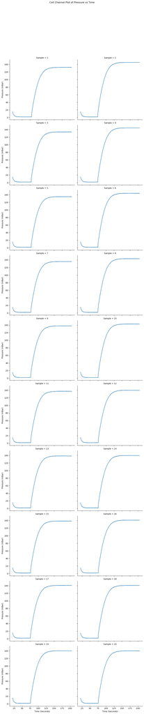

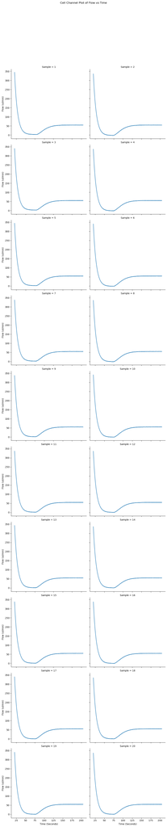

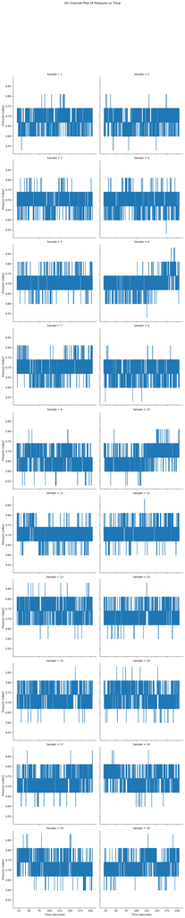

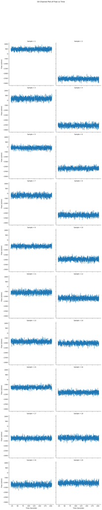

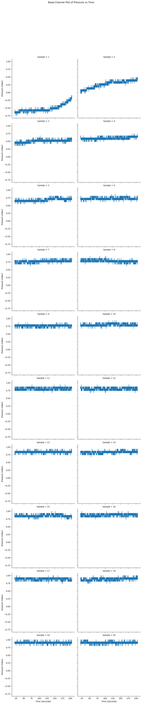

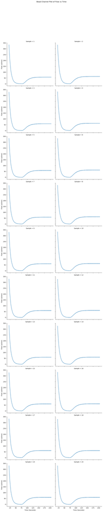

```python
plot_flow_data()
```

- The function `getNewScalingFactor(num_samples,start_time,end_time)` can be used to get the average flow rates between the `start_time` and `end_time` in seconds.
- We want the most stable time interval in the plots for making this calculation. Therefore, will use a `start_time` of 175 and `end_time` of 205.
  - Change this interval if necessary.
- We recommend repeating the previous schedule again if some of the samples did not result in stable flows.
- Execute the cell below to get the values.

```python
def getNewScalingFactor(num_samples,start_time,end_time):
    beadFlowAverage=0
    cellFlowAverage=0
    oilFlowAverage=0
    for num in (list(range(num_samples))):
        cellFlow,beadFlow,oilFlow=(get_average_flow_measurments(start_time,end_time,-1*num))
        cellFlowAverage+=cellFlow
        beadFlowAverage+=beadFlow
    cellFlowAverage=cellFlowAverage/num_samples
    beadFlowAverage=beadFlowAverage/num_samples
    print("Cell Channel Average Flow Rate:",cellFlowAverage)
    print("Bead Channel Average Flow Rate:",beadFlowAverage)
    newScalingFactor=cellFlowAverage/beadFlowAverage
    return(newScalingFactor)
newScalingFactor=getNewScalingFactor(num_samples,175,205)#Change start and end time if necessary.
print("The new Scaling Factor is:",newScalingFactor)
```

```
Cell Channel Average Flow Rate: 55.02586982289277
Bead Channel Average Flow Rate: 60.17110337108723
The new Scaling Factor is: 0.9144899584695536
```

- Lets repeat the measurement but this time using our calculated scaling factor.

```python
num_samples=20
scheduleList=[(bead_channel_calibration,num_samples,205.0,newScalingFactor)]
execute_schedules(scheduleList,10.0)
```

```
Valve Controller 1 State successfully changed!
0 0 0 0 0 0 0 0
Valve Controller 2 State successfully changed!
0 0 0 0 0 0 0 0
Valve Controller 3 State successfully changed!
0 0 0 0 0 0 0 0
Schedule 1 Started at 2024-11-15 18:53:00.923038
Bead Channel Calibration
Valve Controller 1 State successfully changed!
0 0 0 0 0 0 0 0
Valve Controller 2 State successfully changed!
0 0 0 0 0 0 0 0
Valve Controller 3 State successfully changed!
0 0 0 0 0 0 0 0
1037.9693603515625
1.2690685987472534
1037.1292724609375
1.3115711212158203
1036.6259765625
1.2265663146972656
1036.367919921875
1.1667487621307373
Valve Controller 1 State successfully changed!
0 0 1 0 0 0 0 0
Valve Controller 2 State successfully changed!
0 1 0 0 0 0 0 0
Valve Controller 3 State successfully changed!
0 0 0 0 0 0 0 0
Schedule 1 Completed at 2024-11-15 18:56:25.964715
Valve Controller 1 State successfully changed!
0 0 1 0 0 0 0 0
Valve Controller 2 State successfully changed!
0 0 0 0 0 0 0 0
Valve Controller 3 State successfully changed!
0 0 0 0 0 0 0 0
Valve Controller 1 State successfully changed!
0 0 0 0 0 0 0 0
Valve Controller 2 State successfully changed!
0 0 0 0 0 0 0 0
Valve Controller 3 State successfully changed!
```

[output cut: 648 more lines]

```
0 0 1 0 0 0 0 0
Valve Controller 2 State successfully changed!
0 1 0 0 0 0 0 0
Valve Controller 3 State successfully changed!
0 0 0 0 0 0 0 0
Schedule 20 Completed at 2024-11-15 20:04:30.973578
Noise Noise
Scheduler has been Shutdown!
If not complete, current schedule will continue executing till it finishes.
Valve Controller 1 State successfully changed!
0 0 1 0 0 0 0 0
Valve Controller 2 State successfully changed!
0 0 0 0 0 0 0 0
Valve Controller 3 State successfully changed!
0 0 0 0 0 0 0 0
```

plot_flow_data()

- Now lets verify the flow rates.
- The measured scaling factor should be close to 1 now.

```python
measuredScalingFactor=getNewScalingFactor(num_samples,175,205)#Change start and end time if necessary.
print("The measured Scaling Factor is:",measuredScalingFactor)
```

```
Cell Channel Average Flow Rate: 54.99944071622774
Bead Channel Average Flow Rate: 54.88453707537477
The measured Scaling Factor is: 1.0020935521546837
```

- This was a success lets next store our scaling factor.
- Our scaling factor is stored in the variable `scalingFactor55ulFicoll`
- Lets print our calculated scaling factor first

```python
print(newScalingFactor)
```

```
0.9144899584695536
```

- Copy and paste this value to the scaling factor variable below
- Execute the cell below to update the `config/beadFlowSensorScalingFactor.py` file.

```python
%%writefile config/beadFlowSensorScalingFactor.py
#Copy numerical value to this variable
scalingFactor55ulFicoll=0.9144899584695536
```

```
Overwriting config/beadFlowSensorScalingFactor.py
```

- Execute the cell below to stop venting.

```python
stop_vent()
```

```
Valve Controller 1 State successfully changed!
0 0 0 0 0 0 0 0
Valve Controller 2 State successfully changed!
0 0 0 0 0 0 0 0
Valve Controller 3 State successfully changed!
0 0 0 0 0 0 0 0
```

- Turn off the House Air Valve. Wait for the pressure to drop to zero.
- Reconnect the Cell Channel Tygon Tubing to Channel 1 on the Pressure Controller and Bead Channel Tygon Tubing to Channel 3.

[figure not shown]

- Disconnect the 110cm PTFE Tubing from the Cell Channel Flow Sensor and connect the Acetone Flush Reservoir to the Cell Channel Flow Sensor Inlet.
- Disconnect the 110cm PTFE Tubing from the Bead Channel Flow Sensor Outlet.
- Without overtightening, reconnect the PTFE Tubing to the Bead Channel Flow Sensor Outlet and Inlet.
- Reconnect the PTFE Tubing from the Lysis Buffer Flush Reservoirs to the Bead Lysis Buffer Flush Valve.

| Reconnect to Bead Channel Flow Sensor Inlet | Reconnect to Bead Channel Flow Sensor Outlet and Lysis Buffer Flush Valve NC Port |
| --- | --- |

- Keep the 110cm PTFE Tubing somewhere for later reuse incase you need to calibrate again.
- Similar to previously described.
  - First Clean the Cell Channel Flow Sensor with 10ml of 40μm Filtered [Distilled Water](https://www.fishersci.com/shop/products/invitrogen-ultrapure-dnase-rnase-free-distilled-water-2/10977023).
  - Then clean the Cell Channel Flow Sensor with 30ml of [HPLC Grade Acetone](https://www.fishersci.com/shop/products/acetone-hplc-fisher-chemical-6/A949SK1).

### Flow Data Plot: Optional

Recorded data can be very useful for troubleshooting problems with the Device. Can be executed at anytime during the run. You can also wait for the Scheduler to Stop Execution before plotting.

1. Main Menu
2. Shutdown The Device

```python
get_chip_stored_pressure_calibration_values()
```

```python
plot_flow_data(True)
```

### Plot Zoomed in Flow Data for Droplet Genereration Period Only: Optional

```python
def plot_channel_data(channel_measurements,type_of_measurement,channel_name,save_plots=False):
    assert type_of_measurement in ("Pressure","Flow")
    if type_of_measurement is "Pressure":
        ylabel="Pressure (mBar)"
    else:
        ylabel="Flow (ul/min)"
    channel_measurement_df=pd.DataFrame(channel_measurements,columns=[type_of_measurement,"Time","Sample"])
    channel_measurement_df=channel_measurement_df[channel_measurement_df.Time>=163.0]
    channel_measurement_df=channel_measurement_df[channel_measurement_df.Time<=223.0]
    print(channel_measurement_df.shape) #Rows and columns
    sub_plots=sns.relplot(x="Time",y=type_of_measurement,col="Sample",col_wrap=2,data=channel_measurement_df,kind="line")
    sub_plots.set_xlabels("Time (Seconds)")
    sub_plots.set_ylabels(ylabel)
    plt.subplots_adjust(top=0.9)
    sub_plots.fig.suptitle("%s Channel Plot of %s vs Time"%(channel_name,type_of_measurement))
    if save_plots is True:
        sub_plots.savefig(channel_name+type_of_measurement+".png",dpi=600)

def plot_flow_data(save_plots=False):
    """Pass the variable save_plots a True value to save the plots to the current working directory.
    By default this is set to False.
    """
    plot_channel_data(cellChannelPressureMeasurements,"Pressure","Cell",save_plots)
    plot_channel_data(cellChannelFlowMeasurements,"Flow","Cell",save_plots)
    plot_channel_data(oilChannelPressureMeasurements,"Pressure","Oil",save_plots)
    plot_channel_data(oilChannelFlowMeasurements,"Flow","Oil",save_plots)
    plot_channel_data(beadChannelPressureMeasurements,"Pressure","Bead",save_plots)
    plot_channel_data(beadChannelFlowMeasurements,"Flow","Bead",save_plots)
```

```python
plot_flow_data(True)
```

### Troubleshooting Section: Optional

You can type in custom commands in this section to Troubleshoot the device. Recommended for Advanced Users only.

```python
cell_sample_flush_valve1.CLOSE()
set_cell_channel_pressure(0.0)
update_valve_states()
```

```
Valve Controller 1 State successfully changed!
0 0 0 0 0 0 0 0 0 0 0 0 0 0 0 0
Valve Controller 2 State successfully changed!
0 0 0 0 0 0 0 0 0 0 0 0 0 0 0 0
```

```python
cell_bypass_valve.OFF()
update_valve_states()
```

```
Valve Controller 1 State successfully changed!
0 1 0 0 0 0 0 0
Valve Controller 2 State successfully changed!
0 0 0 0 0 0 0 0
Valve Controller 3 State successfully changed!
0 0 0 0 0 0 0 0
```

```python
reset_valve_states()
```

```
Valve Controller 1 State successfully changed!
0 0 0 0 0 0 0 0
Valve Controller 2 State successfully changed!
0 0 0 0 0 0 0 0
Valve Controller 3 State successfully changed!
0 0 0 0 0 0 0 0
```

```python
set_cell_channel_pressure(0.0)
stop_flushing_all_channels()
```

```python
oil_bypass_valve.OFF()
update_valve_states()
```

```
Valve Controller 1 State successfully changed!
0 0 0 0 0 0 0 0 0 0 0 0 0 0 0 0
Valve Controller 2 State successfully changed!
0 0 0 0 1 0 0 0 0 0 0 0 0 0 0 0
```

```python
stop_vent()
```

```
Stop Vent Executed!
Valve Controller 1 State successfully changed!
0 0 0 0 0 0 0 0
Valve Controller 2 State successfully changed!
0 0 0 0 0 0 0 0
Valve Controller 3 State successfully changed!
0 0 0 0 0 0 0 0
```

```python
set_oil_channel_pressure(0.0)
```

```python
reset_valve_states()
```

```
Valve Controller 1 State successfully changed!
0 0 0 0 0 0 0 0 0 0 0 0 0 0 0 0
Valve Controller 2 State successfully changed!
0 0 0 0 0 0 0 0 0 0 0 0 0 0 0 0
```

```python
#Add Test Code Here
time.sleep(90*60.0)
dry_cell_channel(30*60.0)
```

[output not shown]

[output cut: 1146 more lines]

```
Noise Noise
Scheduler has been Shutdown!
If not complete, current schedule will continue executing till it finishes.
Valve Controller 1 State successfully changed!
0 0 0 0 0 0 0 0 0 0 0 0 0 0 0 0
Valve Controller 2 State successfully changed!
0 0 0 0 0 0 0 1 0 0 0 0 0 0 0 0
Valve Controller 1 State successfully changed!
0 0 0 0 0 0 0 0 0 0 0 0 0 0 0 0
Valve Controller 2 State successfully changed!
0 0 0 0 0 0 0 1 0 0 0 0 0 0 0 0
Valve Controller 1 State successfully changed!
0 0 0 0 0 0 0 0 0 0 0 0 0 0 0 0
Valve Controller 2 State successfully changed!
0 0 0 0 0 0 0 0 0 0 0 0 0 0 0 0
```

Execute the Cell Below to Shutdown the Device.

- You should restart the Kernel and Reinitialize all instruments if you have already initiated shutdown.
- Make sure the Compressed Air Gun, House Air and Gas Cylinder are all Turned off and the Depressurized.
- Press the Trigger for the Compressed Air Gun to completely depressurize it after turning off the Pressure.
1. Main menu
2. Start

```python
stop_vent()
%run -i config/deviceShutdown.py
time.sleep(5.0)
```

```
Stop Vent Executed!
Valve Controller 1 State successfully changed!
0 0 0 0 0 0 0 0 0 0 0 0 0 0 0 0
Valve Controller 2 State successfully changed!
0 0 0 0 0 0 0 0 0 0 0 0 0 0 0 0
Stop Vent Executed!
Valve Controller 1 State successfully changed!
0 0 0 0 0 0 0 0 0 0 0 0 0 0 0 0
Valve Controller 2 State successfully changed!
0 0 0 0 0 0 0 0 0 0 0 0 0 0 0 0
Pressure Controller Connection Closed!
Valve Controller 1 Connection Closed!
Valve Controller 2 Connection Closed!
Cell Channel Flow meter Connection Closed!
Bead Channel Flow meter Connection Closed!
Bead Channel Vortex Connection Closed!
Oil Channel Flow meter Connection Closed!
Magnetic Stirrer Connection Closed!
Connection to the Robot closed successfully!
Connection to the Droplet Collector closed successfully!
Connection to the Vortex Relay closed successfully!
```